# Chicago Bulls Analysation

Jie Cai

2023-05-07

# Overview / Background

Basketball is a team sport, which was invented by james naismith in 1891. The concept of basketball came from other sports, such as football, hockey and American football, and the limitation of weather. Basketball was originally an indoor sport, with nine players on each team, which enabled people to play indoors in cold winter. Basketball has slowly become popular in the US and played as an informal outdoor game in some areas. Today, basketball has become one of the most famous and popular sports in the world. The National Basketball Association (NBA) is not only a professional basketball league in the United States, but also a dream place for most basketball players.

# Aim

Since we recently gathered many young players, the average age of our team is 24. In such a young team, there are many opportunities to cultivate our players into the best players in the league. We can also fill in some new faces and add some experienced players to our team. Their experiences, skills and views can benefit our team and produce good team chemistry effect.

This analysis mainly focuses on finding out the limitations and shortcomings of our team and the differences between us and other teams. The analysis of players in the whole league is also carried out in this analysis. According to our current salary budget, find out some potential players suitable for our team, and optimize the expenditure according to the skills of the players. Hope those changes can help the team to move forward and aim for better ranking in the next season.

# Data

There are 4 datasets been used in this analysis: - 2018-19_nba_player-statistics - 2018-19_nba_player-salaries - 2018-19_nba_team-payroll - 2018-19_nba_team-statistics_2

The salaries data and payroll data were obtained from Hoopshype website, and the player statistics and team satatistic data were found from the Basketball-Reference site.

The variables used in the alaysis are: 2018-19_nba_player-statistics.csv  
- player_name : Player Name - Pos : (PG = point guard, SG = shooting guard, SF = small forward, PF = power forward, C = center) - Age : Age of Player at the start of February 1st of that season. - Tm : Team - G: Games - MP : Minutes Played - FG : Field Goals - FGA : Field Goal Attempts - FG. : Field Goal Percentage - X3P : 3-Point Field Goals - X3PA : 3-Point Field Goal Attempts - X3P. : FG% on 3-Pt FGAs - X2P : 2-Point Field Goals - X2PA : 2-point Field Goal Attempts - X2P. : FG% on 2-Pt FGAs - FT : Free Throws - FTA : Free Throw Attempts - FT. : Free Throw Percentage - ORB : Offensive Rebounds - DRB : Defensive Rebounds - TRB : Total Rebounds - AST : Assists - STL : Steals - BLK : Blocks - TOV : Turnovers - PF : Personal Fouls - PTS : Points

2018-19_nba_team-statistics_2: - Rk: Ranking - Team: Team Name - G: Games - MP : Minutes Played - FG : Field Goals - FGA : Field Goal Attempts - FG. : Field Goal Percentage - X3P : 3-Point Field Goals - X3PA : 3-Point Field Goal Attempts - X3P. : FG% on 3-Pt FGAs - X2P : 2-Point Field Goals - X2PA : 2-point Field Goal Attempts - X2P. : FG% on 2-Pt FGAs - FT : Free Throws - FTA : Free Throw Attempts - FT. : Free Throw Percentage - ORB : Offensive Rebounds - DRB : Defensive Rebounds - TRB : Total Rebounds - AST : Assists - STL : Steals - BLK : Blocks - TOV : Turnovers - PF : Personal Fouls - PTS : Points

2018-19_nba_player-salaries: - player_id : unique player identification number - player_name : player name - salary : year salary in $USD

2018-19_nba_team-payroll: - team_id : unique team identification number - team : team name - salary : team payroll budget in 2019-20 in $USD

Notes, all the “%” has been replaced by “.” in dataset. # Analysis:

## Reading data:

```r
library(tidyverse)
library(broom)
salaries_1819 <- read.csv("2018-19_nba_player-salaries.csv")
player_1819 <- read.csv("2018-19_nba_player-statistics.csv")
team_1819 <- read.csv("2018-19_nba_team-statistics_2.csv")
payroll_1920 <- read.csv("2019-20_nba_team-payroll.csv")
```

## Finding NA

```r
sum(is.na(salaries_1819))
```

```
## [1] 0
```

```r
sum(is.na(player_1819))
```

```
## [1] 117
```

```r
sum(is.na(team_1819))
```

```
## [1] 0
```

```r
sum(is.na(payroll_1920))
```

```
## [1] 0
```

## Analysis difference between others and Chicago Bulls

By comparing the statistical data between us and others, we can find out what the weaknesses are and try to improve them. By comparing, we can also see what we are good at and stick to it.

Find the average value for all variables and compare it with the data of our team. A new data set has been created, which only containing team rankings from 24 to 27. This dataset may help to find out what are the most significant factors that we need to focus on in order to help with our ranking next season.

## Tidy the team dataset

In the team dataset, there are few variables, such as 3P, 3PA and 3P. can cause multicollinearity, due to the relationship among the variables. In order to prevent multicollinearity, the rate variables, such as FG.XP3., XP2.,FT. were been used and their related varaibles （FG,FGA, 3P, X3PA, X2, X2PA, FT, FTA) are been removed. Variable G (Game) and MP (Minutes played) also been removed, as those varaibels are almost the same for all the team, thus not significant to the data analysis.

```r
team <- team_1819%>%
  select(c("Rk","Team","FG.","X3P.","X2P.","FT.","TRB", "AST","STL","BLK","TOV","PF"))

chi_team1 <- team[27,-1] %>%  pivot_longer(
  cols = !Team,
  names_to = "chi_data",
  values_to = "chi_result")

mean_data <- team%>%mutate(team="team",mean(FG.),mean(X3P.),
                           mean(X2P.),mean(FT.), mean(TRB), mean(AST),
                           mean(STL),mean(BLK),  mean(TOV), mean(PF))

mean_data <- tibble(mean_data[1,13:23])
mean_data <- mean_data %>%  pivot_longer(
  cols = !team,
  names_to = "mean",
  values_to = "result")
mean_data$result <-round(mean_data$result,digits = 3)
comp <- chi_team1%>%mutate(mean_result=mean_data$result)
comp <- comp%>%mutate(diff=chi_result-mean_result)
comp
```

```
## # A tibble: 10 × 5
##    Team          chi_data chi_result mean_result       diff
##    <chr>         <chr>         <dbl>       <dbl>      <dbl>
##  1 Chicago Bulls FG.           0.453       0.46    -0.00700
##  2 Chicago Bulls X3P.          0.351       0.356   -0.00500
##  3 Chicago Bulls X2P.          0.496       0.52    -0.0240
##  4 Chicago Bulls FT.           0.783       0.767    0.0160
##  5 Chicago Bulls TRB        3517        3704.    -187.
##  6 Chicago Bulls AST        1796        2016.    -220.
##  7 Chicago Bulls STL         603         626.     -23.0
##  8 Chicago Bulls BLK         351         406.     -55.2
##  9 Chicago Bulls TOV        1159        1155.       4.20
## 10 Chicago Bulls PF         1663        1714.     -51.2
```

```r
write_csv(comp,file="modified_dataset/chicago vs league mean.csv")
```

## Team data comparision between rank 26 to rank 27

```r
team_26 <- team[26,-1] %>%pivot_longer(
  cols = !Team,
  names_to = "data",
  values_to = "result")
rk24_26 <- chi_team1%>%mutate(diff_rk2627=chi_result-team_26$result)

team_25 <- team[25,-1] %>%pivot_longer(
  cols = !Team,
  names_to = "data",
  values_to = "result")
rk24_26 <- rk24_26%>%mutate(diff_rk2527=chi_result-team_25$result)

team_24 <- team[24,-1] %>%pivot_longer(
  cols = !Team,
  names_to = "data",
  values_to = "result")
rk24_26 <- rk24_26%>%mutate(diff_rk2427=chi_result-team_24$result)
rk24_26
```

```
## # A tibble: 10 × 6
##    Team          chi_data chi_result diff_rk2627 diff_rk2527 diff_rk2427
##    <chr>         <chr>         <dbl>       <dbl>       <dbl>       <dbl>
##  1 Chicago Bulls FG.           0.453     0.00300     0.0130     -0.00100
##  2 Chicago Bulls X3P.          0.351     0.00200     0.00300    -0.00500
##  3 Chicago Bulls X2P.          0.496    -0.0130     -0.00400    -0.0130
##  4 Chicago Bulls FT.           0.783     0.0880      0.0360      0.00100
##  5 Chicago Bulls TRB        3517      -283        -171        -207
##  6 Chicago Bulls AST        1796      -195         -49        -299
##  7 Chicago Bulls STL         603       -24          34          60
##  8 Chicago Bulls BLK         351       -97          20         -94
##  9 Chicago Bulls TOV        1159       -49          24          77
## 10 Chicago Bulls PF         1663       -49        -148         137
```

As the rk24_26 shows the comparision between Chicaogo Bulls (rk27) with teams rank from 24 to 26. The result also show that if Chicago Bulls want to move up by at least one place next season, we need to make more efforts in rebounding and assists.

# Solving Rebounds and Assists Issue (Seek for suitable players)

## combine data player and salaries

By combining the player salaries date together with the players skills data, we can test the relationship between salaries and other factors, and thus we can figure out are more skilled player will obtain higher salaries, or the players’ age may also affect the their salaries.

```r
player <- left_join(player_1819,salaries_1819)
levels(as.factor(player$Pos))
```

```
##  [1] "C"     "C-PF"  "PF"    "PF-C"  "PF-SF" "PG"    "SF"    "SF-SG" "SG"
## [10] "SG-PF" "SG-SF"
```

## Fina missing value ‘NA’

since there are 161 missing value, 22 players have no player id and salary indicated. Thus, those players can be currently not in the league but do have talent. We may offer them a sound salary and place them as backup players. To prevent removed these potential player, all the NA value will be fill with ‘0’ and create a no salaries dataset for those no salaries indicated players.

```r
colnames(player)[apply(player, 2, anyNA)]
```

```
## [1] "FG."       "X3P."      "X2P."      "eFG."      "FT."       "player_id"
## [7] "salary"
```

```r
colSums(is.na(player))
```

```
## player_name         Pos         Age          Tm           G          GS
##           0           0           0           0           0           0
##          MP          FG         FGA         FG.         X3P        X3PA
##           0           0           0           6           0           0
##        X3P.         X2P        X2PA        X2P.        eFG.          FT
##          47           0           0          15           6           0
##         FTA         FT.         ORB         DRB         TRB         AST
##           0          43           0           0           0           0
##         STL         BLK         TOV          PF         PTS   player_id
##           0           0           0           0           0          22
##      salary
##          22
```

```r
sum(is.na(player))
```

```
## [1] 161
```

```r
#fill in NA value
player[is.na(player)] <- 0
no_salary <- filter(player, salary=="0")
```

## Tidy dataset

As some players might played for different teams, for these type of players, their total statistic data are stored in the row with team variables as TOT. To prevent duplicates analysis apply to these cross-team players, we are going to retain the row with TOT. After remove repeated players in the dataset. The playe dataset has been divided in to two dataset, one for players with salaries and the other dataset is for players with no salaries indicated.

```r
player_tot <- player[grepl('TOT', player$Tm),]

no_salary<- no_salary[!(no_salary$player_name %in% player_tot$player_name),]
no_salary <- filter(player_tot, salary=="0")%>%full_join(no_salary)
```

[output not shown]

```r
player2 <- player[!(player$player_id %in% player_tot$player_id),]
player <- full_join(player2,player_tot)
```

[output not shown]

```r
write_csv(no_salary,file="modified_dataset/players with no_salary.csv")
write_csv(player,file="modified_dataset/players with salary.csv")
```

As Basketball has 5 key positions, thus the player dataset has been divied in to 5 different dataset, each of them represent 1 position type. Some players play more than 1 position, in this case, they are been placed in more than 1 positions’ dataset. Even though thay have been analysis more than 1 time, but since the multiple analysation are not conduce in same dataset, thus no negative effect.

```r
levels(as.factor(player$Pos))
```

```
##  [1] "C"     "C-PF"  "PF"    "PF-C"  "PF-SF" "PG"    "SF"    "SF-SG" "SG"
## [10] "SG-PF" "SG-SF"
```

```r
pg <- player[grepl('PG', player$Pos),]
sg<- player[grepl('SG', player$Pos),]
sf<- player[grepl('SF', player$Pos),]
pf<- player[grepl('PF', player$Pos),]
cent <- player[grepl('C', player$Pos),]
write_csv(pg,file="modified_dataset/pg.csv")
write_csv(sg,file="modified_dataset/sg.csv")
write_csv(sf,file="modified_dataset/sf.csv")
write_csv(pf,file="modified_dataset/pf.csv")
write_csv(cent,file="modified_dataset/cent.csv")
```

## Rebound and Assists

Since the comparison tables shows Chicago Bulls has weakness on rebounds and assists. Finding good players with higher rebound and assist accross 5 different positions may help to solve the team weakness. Players data has a varaible name eFG., this variables could have multicollinearity relationship with FG. amd X3P., thus before finalise the center players data, the multicollinearity test is conducted

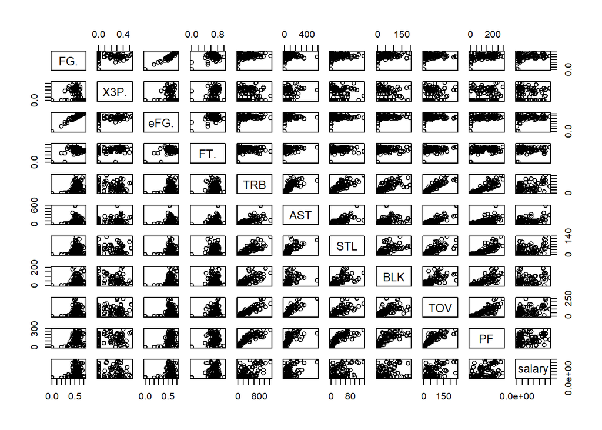

```r
#remove, multicollinearity varaiblescent
c_fit <- lm(log(salary)~FG.+X3P.+eFG.+FT.+TRB+AST+STL+BLK+TOV+PF, data=cent)
pairs(formula=~FG.+X3P.+eFG.+FT.+TRB+AST+STL+BLK+TOV+PF+salary,data=cent)
```

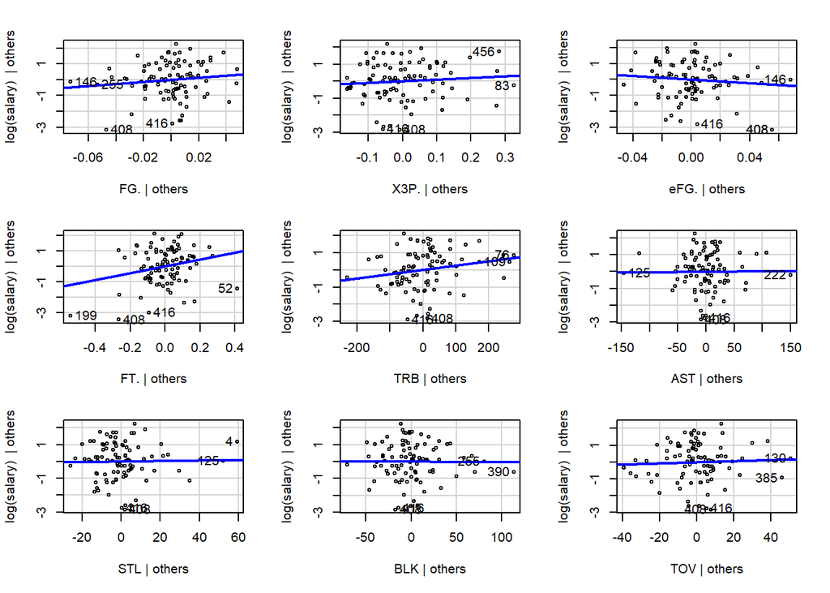

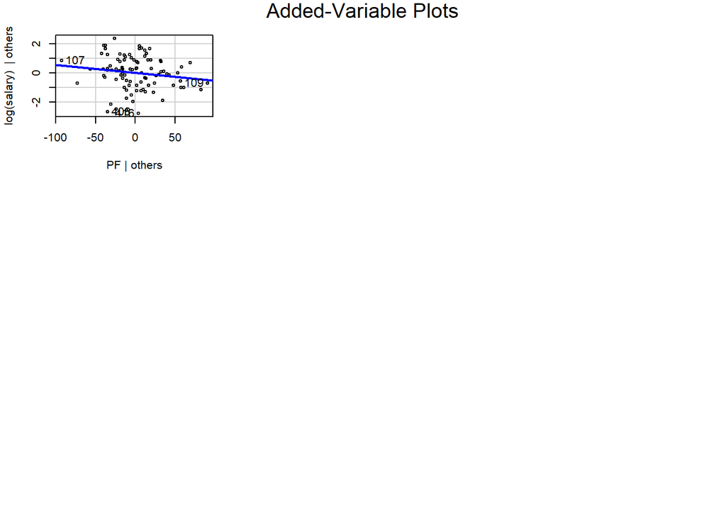

```r
car::avPlots(c_fit) # test linearity / covaraince
```

```r
sqrt(car::vif(c_fit))
```

```
##      FG.     X3P.     eFG.      FT.      TRB      AST      STL      BLK
## 5.778689 1.617507 5.694027 1.274161 3.214752 2.366559 2.208466 1.659694
##      TOV       PF
## 3.647232 2.410240
```

Both Scatter plot and vif test show that there are linear relationship between FG. and eFG. This is because eFG.is been calculated based on FG. and either X3P. or X2P.. Since X3P. doesn’t have linear relationship with eFG. thus, we keep FG. instead eFG. to prevent lost of shooting data.

## Finding Center player

```r
#remove eFG.
new_cent <- cent%>%subset(select=c("player_name","Tm","MP","FG.","X3P.","FT.","TRB", "AST","STL","BLK","TOV","PF","salary"))%>%arrange(desc(TRB))
chi_cent <- new_cent[grepl('CHI', new_cent$Tm),]%>%
  select(player_name,MP,TRB,AST,BLK,TOV,PF,salary)
chi_cent
```

```
##          player_name   MP TRB AST BLK TOV  PF   salary
## 47    Wendell Carter 1110 307  78  58  65 152  4446840
## 49       Robin Lopez 1606 286  89  78  96 124 14357750
## 62 Cristiano Felicio  746 218  37   7  33  69  8470980
```

From the Chi_cent data frame, we can see that Robin Lopez who takes the highest salary within the center players, contributes second lowest number of rebounds. Cristiano Felicio has the lowest rebounds and assist out of three and the salary is sits at the middle range. But the total minute played by Crustiano is much less than others. Wendell Carter made much contribution on rebounds but he also made a lot personal fouls. By looking at above table comparision, it can be better for us to find one or two center player to replace some of our current players.

```r
#set cent at mean value
cent_TRB <- filter(new_cent,TRB>mean(player$TRB),PF<mean(player$PF))%>%
  select(player_name,MP,TRB,AST,BLK,TOV,PF,salary)%>%
  arrange(TRB)
cent_TRB
```

```
##         player_name   MP TRB AST BLK TOV PF   salary
## 1 Cristiano Felicio  746 218  37   7  33 69  8470980
## 2       Joakim Noah  693 238  89  31  50 96 20261172
## 3    Kenneth Faried  728 250  20  23  33 82 14242782
## 4     Marcin Gortat  751 261  65  24  50 92 13565218
## 5  Boban Marjanovic  681 265  54  27  59 90  9490740
## 6     Jahlil Okafor  935 278  40  40  52 96  1567007
## 7  Tristan Thompson 1198 438  86  16  59 89 17469565
```

```r
#salary different
(14357750+8470980)-(1567007+17469565)
```

```
## [1] 3792158
```

Thus the replacement among Robin Lope and Cristiano Felicio with Jahlil Okafor and Tristan Thompson can be a good decision.

## Finding point guard

```r
new_pg <- pg%>%subset(select=c("player_name","Tm","MP","FG.","X3P.","FT.","TRB", "AST","STL","BLK","TOV","PF","salary"))%>%arrange(desc(AST))
chi_pg <- new_pg[grepl('CHI', new_pg$Tm),]%>%
  select(player_name,MP,TRB,AST,BLK,TOV,PF,salary)
chi_pg
```

```
##            player_name   MP TRB AST BLK TOV  PF  salary
## 32           Kris Dunn 1389 187 277  21 104 166 4221000
## 34    Ryan Arcidiacono 1961 219 269   4  63 171 1349383
## 56  Shaquille Harrison 1430 222 139  30  60 124 1325531
## 101         Tyler Ulis    1   0   0   0   0   0   77250
```

The chi_pg table shows Kris Dunn has highest AST and TOV out of four point guard, he also highest salary among the point guard. In order to find replacement, we need to find someone has similary skill record as Kris, but lower salary, or bette skill with slighly higher salary.

```r
pg_AST <- filter(new_pg,TRB>200,AST>300,salary<4500000)%>%
  select(player_name,MP,TRB,AST,BLK,TOV,PF,salary)%>%
  arrange(AST)
pg_AST
```

```
##        player_name   MP TRB AST BLK TOV  PF  salary
## 1    Elfrid Payton 1250 220 320  17 112  81 3000000
## 2     Jamal Murray 2447 317 363  27 158 153 3499800
## 3 Tomas Satoransky 2164 279 399  13 120 172 3129187
```

By comparing table pg_AST and chi_pg, it can be a good idea to replace Kris, Shaquille and Tyler with Elfrid and Jamal.

```r
#salary different:
(4221000+1325531+77250-3000000-3499800)+3792158
```

```
## [1] 2916139
```

## Finding shoot guard

```r
new_sg <- sg%>%subset(select=c("player_name","Tm","MP","FG.","X3P.","FT.","TRB", "AST","STL","BLK","TOV","PF","salary"))%>%arrange(desc(AST))
chi_sg <- new_sg[grepl('CHI', new_sg$Tm),]%>%
  select(player_name,MP,TRB,AST,BLK,TOV,PF,salary)
chi_sg
```

```
##          player_name   MP TRB AST BLK TOV  PF   salary
## 11       Zach LaVine 2171 294 283  26 215 140 19500000
## 79  Antonio Blakeney  829 106  42   9  35  41  1349383
## 102     Rawle Alkins  120  26  13   0   8   7    77250
## 108  Brandon Sampson  214  16  10   3  12  19    77250
```

The chi_sg table shows Zach LaVine who takes highest salary has similar skill results as Kris. In this case, we may replace Zach with better skill or similar skill but lower salary wanted.

```r
sg_AST <- filter(new_sg,TRB>250,AST>300,salary<15000000)%>%
  select(player_name,MP,TRB,AST,BLK,TOV,PF,salary)%>%
  arrange(AST)
sg_AST
```

```
##        player_name   MP TRB AST BLK TOV  PF  salary
## 1      Dwyane Wade 1885 285 301  38 166 118 2393887
## 2 Donovan Mitchell 2598 316 322  31 218 208 3111480
## 3      Luka Doncic 2318 563 429  25 247 137 6569040
## 4     Devin Booker 2242 265 433  13 264 200 3314365
```

```r
#salary different:
(19500000-2393887-3111480-6569040-3314365)+2916139
```

```
## [1] 7027367
```

## Finding small forward and power forward

```r
new_sf <- sf%>%subset(select=c("player_name","Tm","MP","FG.","X3P.","FT.","TRB", "AST","STL","BLK","TOV","PF","salary"))
chi_sf <- new_sf[grepl('CHI', new_sf$Tm),]%>%
  select(player_name,MP,TRB,AST,BLK,TOV,PF,salary)
chi_sf
```

```
##            player_name  MP TRB AST BLK TOV PF  salary
## 201 Chandler Hutchison 895 185  34   6  25 59 1991520
## 356     JaKarr Sampson 127  32   4   3   4  8   85457
```

```r
sf_AT <- filter(new_sf,TRB>mean(player$TRB),AST>mean(player$AST),salary<(1991520+7027367))%>%
  select(player_name,MP,TRB,AST,BLK,TOV,PF,salary)
sf_AT
```

```
##       player_name   MP TRB AST BLK TOV  PF  salary
## 1   Kyle Anderson 1281 251 128  37  58 112 8641000
## 2   Mikal Bridges 2417 264 173  38  70 201 3557400
## 3     Jae Crowder 2166 384 133  31  85 170 7305825
## 4  Brandon Ingram 1760 267 154  31 129 149 5757120
## 5   Royce O'Neale 1671 285 124  24  70 172 1378242
## 6      Cedi Osman 2444 357 195  11 114 195 2775000
## 7    Jayson Tatum 2455 477 168  57 122 168 6700800
## 8 Justise Winslow 1959 355 282  19 142 177 3448926
```

As our small forward players do not look nice, the data a less than league mean, thus picking player based on the league mean. By looking at the sf_AT table, Cedi, Royce and Justise could be our potiential player. But before picking them, the analysis on power forward may needed.

```r
new_pf <- pf%>%subset(select=c("player_name","Tm","MP","FG.","X3P.","FT.","TRB", "AST","STL","BLK","TOV","PF","salary"))
chi_pf <- new_pf[grepl('CHI', new_pf$Tm),]%>%
  select(player_name,MP,TRB,AST,BLK,TOV,PF,salary)
chi_pf
```

```
##         player_name   MP TRB AST BLK TOV  PF  salary
## 267 Lauri Markkanen 1682 470  75  33  85 122 4536120
```

```r
pf_AT <- filter(new_pf,TRB>mean(player$TRB),AST>mean(player$AST),salary<5000000)%>%
  select(player_name,MP,TRB,AST,BLK,TOV,PF,salary)
pf_AT
```

```
##     player_name   MP TRB AST BLK TOV  PF  salary
## 1  John Collins 1829 595 121  39 120 199 2299080
## 2    Jeff Green 2097 309 137  39 101 160 2393887
## 3    Kyle Kuzma 2314 382 178  26 133 170 1689840
## 4 Pascal Siakam 2548 549 248  52 154 241 1544951
## 5   Noah Vonleh 1722 528 129  51  88 174 1621415
## 6   Dario Saric 2023 457 127   9  97 182 2526840
```

Comparing between our team power forward and the selected power forward, retain our small forward Chandler and add in Justise Winslow. Changing our power forward to Noah and Dario.

## Payroll changes

```r
(14357750+8470980)-(1567007+17469565)+(4221000+1325531+77250-3000000-3499800)+(
19500000-2393887-3111480-6569040-3314365)-3448926+(4536120-1621415-2526840)
```

```
## [1] 3966306
```

# Conclusion

After the analysis among 5 different positions and team data, there are number of changing players in the next season.

Those players are:

Center: -Robin Lope to by Jahlil Okafor - Cristiano Felicio to Tristan Thompson

Point Guard: - Kris Dunn to Elfrid Payton - Shaquille Harrison to Jamal Murray

Shoot Guard -Zach LaVine to Dwyane Wade + Donovan Mitchell + Luka Doncic + Devin Booker

Small Forward - add in Justise Winslow

Power Forward - change Lauri Markkanen to Noah Vonleh + Dario Saric